# homework_04

### Exercise 1

Let $\theta_1$ and $\theta_2$ be real valued parameters of the model

$$ y = \frac{\theta_1 x}{\theta_2 + x}. $$

a. Choose two suitable prior distributions for $\theta_1$ and $\theta_2$ and use HMC algorithm to find their posterior distributions, conditioning on the observations

$$ x=(28,55,110,138,225,375)\\ y=(0.053,0.060,0.112,0.105,0.099,0.122). $$

b. Discuss how different parameters for both priors and the HMC algorithm lead to different estimates.

c. Plot the most reliable posterior distributions, according to convergence checks on the traces.

```python
import torch
import numpy as np
import random
import matplotlib.pyplot as plt
import seaborn as sns
import pyro
import pyro.distributions as dist
from pyro.infer.mcmc import MCMC, HMC, NUTS
pyro.set_rng_seed(0)
```

**Solution:**

a, b. Given

$$ y = \frac{\theta_1 x}{\theta_2 + x} $$

I consider the following model:

- Given as known $\theta_1$ $\theta_2$ and x, the probability to having a y is distributed as a normal centered on $ y(x) = \frac{\theta_1 x}{\theta_2 + x} $ and $\sigma = 1$:

  $$y | \theta_1, \theta_2, x \sim \mathcal{N}(y(x),1) $$
- We assume for the prior distribution $\pi(\theta_1, \theta_2 | x)$ that, given the observation x, the random variables $\theta_1$ and $\theta_2$ are indipendent:

  $$\pi(\theta_1, \theta_2 | x) = \pi(\theta_1 | x) \pi(\theta_2 | x) $$
- Then, by applying Bayes' Theorem we end up with

  $$ p (\theta_1, \theta_2 | y, x ) = \frac{p(y | \theta_1, \theta_2) \pi(\theta_1 | x) \pi(\theta_2 | x) }{p(y,x)} $$

I decide to use the following three distributions for the priors of $\theta_1$ and $\theta_2$:

- Gamma Distribution
- Exponential Distribution
- LogNormal Distribution

I justify this assumption by the fact that I consider that both $\theta_1$ and $\theta_2$ positives. All choices of the hyperparameters are taken in order to have a distribution that could take very likely a broad range of values, since I have no specifications about $\theta_1$ and $\theta_2$.

- $\theta_1 \sim Gamma(7.5, 1.0) $ and $ \theta_2 \sim Gamma(7.5, 1) $.

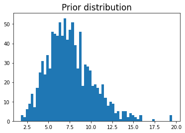

```python
t = torch.zeros(1000)

for i in range(0,1000):
    t[i] = pyro.sample("t"+str(i), dist.Gamma(7.5,1))

plt.hist(t, bins=60)
plt.title("Prior distribution", fontsize=17)
plt.show()
```

```python
x_data = torch.tensor([28,55,110,138,225,375])

y_data = torch.tensor([0.053,0.060,0.112,0.105,0.099,0.122])

def scale(x = x_data):

    # models weight in terms of the initial guess
    theta_1 = pyro.sample("theta_1", dist.Gamma(7.5,1))
    theta_2 = pyro.sample("theta_2", dist.Gamma(7.5,1))
    yhat = (theta_1*x)/(theta_2+x)
    #models measurment process
    y = pyro.sample("y", dist.Normal(yhat,1))

    return y
```

```python
conditioned_scale = pyro.condition(scale, data={"y": y_data})
```

```python
hmc_kernel = HMC(model=conditioned_scale) # transition kernel
mcmc_gamma = MCMC(hmc_kernel, num_samples=500, warmup_steps=1000, num_chains=3)

posterior = mcmc_gamma.run()

# dictionary of sampled values
print(mcmc_gamma.get_samples().keys())
```

```
dict_keys(['theta_1', 'theta_2'])
```

```python
mcmc_gamma.summary()
```

```
                mean       std    median      5.0%     95.0%     n_eff     r_hat
   theta_1      1.15      0.33      1.13      0.65      1.70     39.20      1.13
   theta_2      8.03      2.87      7.62      3.60     12.58    207.27      1.00

Number of divergences: 0
```

```python
def plot_thetas_2d(mcmc):
    expected_theta_1 = mcmc['theta_1'].mean().item()
    expected_theta_2 = mcmc['theta_2'].mean().item()

    print("expected theta_1 =", expected_theta_1)
    print("expected theta_2 =", expected_theta_2)

    with sns.axes_style("white"):
        plot = sns.jointplot(mcmc['theta_1'], mcmc['theta_2'], kind="hex", color="blue");

    plt.xlabel(" theta_1 ")
    plt.ylabel(" theta_2 ")
    plot.ax_joint.axvline(x=expected_theta_1, linewidth = 2, color="g", linestyle='--')
    plot.ax_joint.axhline(y=expected_theta_2, linewidth = 2, color="g", linestyle='--')
```

```
GAMMA PRIOR
expected theta_1 = 1.1475728750228882
expected theta_2 = 8.034004211425781
```

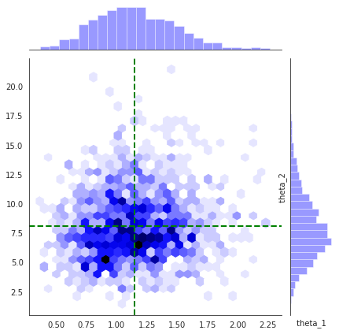

```python
mcmc_samples_gamma = mcmc_gamma.get_samples(group_by_chain=True)
print("GAMMA PRIOR")

plot_thetas_2d(mcmc_samples_gamma)

plt.show()
```

$\theta_1 \sim Exp(0.1) $ and $ \theta_2 \sim Exp(0.1) $.

```python
t = torch.zeros(1000)

for i in range(0,1000):
    t[i] = pyro.sample("t"+str(i), dist.Exponential(0.1))

plt.hist(t, bins=60)
plt.title("Prior distribution", fontsize=17)
plt.show()
```

[output not shown]

```python
def scale_exp(x = x_data):

    # models weight in terms of the initial guess
    theta_1 = pyro.sample("theta_1", dist.Exponential(0.1))
    theta_2 = pyro.sample("theta_2", dist.Exponential(0.1))
    yhat = (theta_1*x)/(theta_2+x)
    #models measurment process
    y = pyro.sample("y", dist.Normal(yhat,1))

    return y
```

```python
conditioned_scale = pyro.condition(scale_exp, data={"y": y_data})
```

```python
hmc_kernel = HMC(model=conditioned_scale) # transition kernel
mcmc_exp = MCMC(hmc_kernel, num_samples=500, warmup_steps=1000, num_chains=3)

posterior = mcmc_exp.run()

# dictionary of sampled values
print(mcmc_exp.get_samples().keys())
```

```
dict_keys(['theta_1', 'theta_2'])
```

```python
mcmc_exp.summary()
```

```
                mean       std    median      5.0%     95.0%     n_eff     r_hat
   theta_1      0.41      0.29      0.36      0.00      0.80    316.05      1.01
   theta_2     10.25     10.26      7.18      0.05     22.98    192.64      1.02

Number of divergences: 0
```

```
EXPONENTIAL PRIOR
expected theta_1 = 0.411272257566452
expected theta_2 = 10.24880599975586
```

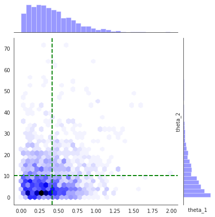

```python
mcmc_samples_exp = mcmc_exp.get_samples(group_by_chain=True)
print("EXPONENTIAL PRIOR")

plot_thetas_2d(mcmc_samples_exp)

plt.show()
```

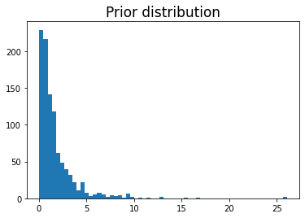

```python
t = torch.zeros(1000)

for i in range(0,1000):
    t[i] = pyro.sample("t"+str(i), dist.LogNormal(0.,1.))

plt.hist(t, bins=60)
plt.title("Prior distribution", fontsize=17)
plt.show()
```

```python
def scale(x = x_data):

    # models weight in terms of the initial guess
    theta_1 = pyro.sample("theta_1", dist.LogNormal(0,1))
    theta_2 = pyro.sample("theta_2", dist.LogNormal(0,1))
    yhat = (theta_1*x)/(theta_2+x)
    #models measurment process
    y = pyro.sample("y", dist.Normal(yhat,1))

    return y
```

```python
conditioned_scale = pyro.condition(scale, data={"y": y_data})
```

```python
hmc_kernel = HMC(model=conditioned_scale) # transition kernel
mcmc_log = MCMC(hmc_kernel, num_samples=500, warmup_steps=1000, num_chains=3)

posterior = mcmc_log.run()

# dictionary of sampled values
print(mcmc_log.get_samples().keys())
```

```
dict_keys(['theta_1', 'theta_2'])
```

```python
mcmc_log.summary()
```

```
                mean       std    median      5.0%     95.0%     n_eff     r_hat
   theta_1      0.33      0.23      0.26      0.07      0.70      4.05      1.30
   theta_2      1.46      1.75      0.97      0.05      3.06    358.69      1.01

Number of divergences: 0
```

```
LOGNORMAL PRIOR
expected theta_1 = 0.3336733877658844
expected theta_2 = 1.460719108581543
```

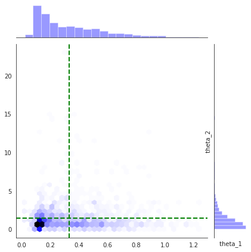

```python
mcmc_samples_log = mcmc_log.get_samples(group_by_chain=True)
print("LOGNORMAL PRIOR")

plot_thetas_2d(mcmc_samples_log)

plt.show()
```

c. By considering `n_eff` and `r_hat` it looks like that the posterior that has an exponential prior of $\theta_1$ and $\theta_2$ seems to have achieved a faster convergence

### Exercise 2

A bivariate Gibbs sampler for a vector $x=(x_1,x_2)$ draws iteratively from the posterior conditional distributions in the following way:

- choose a starting value $p(x_1|x_2^{(0)})$
- for each iteration $i$:
  - draw $x_2(i)$ from $p(x_2|x_1^{(i-1)})$
  - draw $x_1(i)$ from $p(x_1|x_2^{(i)})$

a. Supposing that samples are drawn from a bivariate normal distribution

$$ {x_1 \choose x_2} \sim \mathcal{N} \Bigg[ {0 \choose 0} , \begin{pmatrix} 1 & \rho \\ \rho & 1 \end{pmatrix} \Bigg], $$

```
implement a Gibbs sampler for $x$ which takes as inputs the number of iterations `iters` and the number of warmup draws `warmup`.
```

b. Use your implementation of Gibbs sampler to infer the parameters $\theta=(\theta_1,\theta_2)$ from **Exercise 1**.

**Solution:**

a. Using the properties of the multivariate normal distribution

$$ x_1|x_2,\: x \text{ ~ } N(\rho x_2,\: 1-\rho^2) \text{ ~ } \rho x_2 + \sqrt{1-\rho^2}N(0,\:1) $$

and

$$ x_2| x_1,\: x \text{ ~ } N(\rho x_1,\: 1-\rho^2) \text{ ~ } \rho x_1 + \sqrt{1-\rho^2}N(0,\:1) $$

Then, given $\rho$ we can implement the `gibbs_sampler` for the random vector $x$ distributed as a bivariate normal distribution:

```python
def gibbs_sampler(rho, iters, warmup):

    #Initialize the variables
    x_1 = torch.zeros(warmup + iters, 1)
    x_2 = torch.zeros(warmup + iters, 1)

    x_2[0] = pyro.sample("x2_0", dist.Normal(0,2))
    x_1[0] = pyro.sample("x1_0", dist.Normal(rho*x_2[0].item(), np.sqrt(1-rho**2)))

    for t in range(1,warmup+iters-1):
        x_2[t] = pyro.sample("x2_"+str(t), dist.Normal(rho*x_1[t-1].item(), np.sqrt(1-rho**2)))
        x_1[t] = pyro.sample("x1_"+str(t), dist.Normal(rho*x_2[t].item(), np.sqrt(1-rho**2)))

    x1 = x_1[warmup:iters]
    x2 = x_2[warmup:iters]

    return x1, x2
```

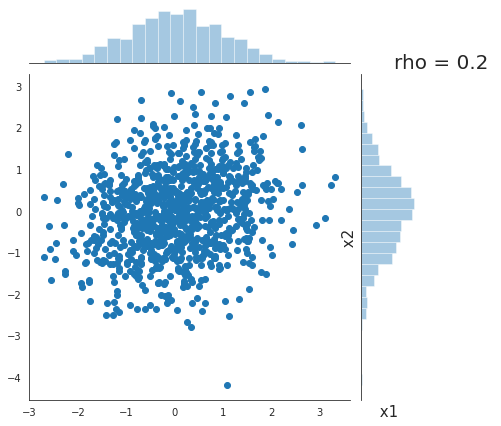

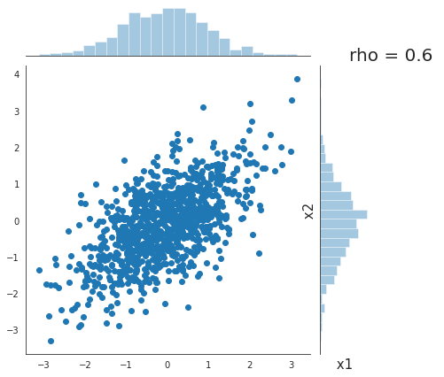

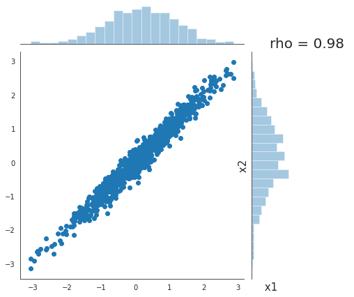

```python
plt.figure(figsize=(16,5))


x1, x2 = gibbs_sampler(0.2, 2000, 1000)

with sns.axes_style("white"):
        sns.jointplot(x1, x2, kind="scatter");

plt.title("rho = 0.2 ", fontsize=20, x = 1.5)
plt.xlabel(" x1 ", fontsize=15)
plt.ylabel(" x2 ", fontsize=15)
plt.show()


x3, x4 = gibbs_sampler(0.6, 2000, 1000)

with sns.axes_style("white"):
        sns.jointplot(x3, x4, kind="scatter");

plt.title("rho = 0.6 ", fontsize=20, x = 1.5)
plt.xlabel(" x1 ", fontsize=15)
plt.ylabel(" x2 ", fontsize=15)
plt.show()

x5, x6 = gibbs_sampler(0.98, 2000, 1000)

with sns.axes_style("white"):
        sns.jointplot(x5, x6, kind="scatter");

plt.title("rho = 0.98 ", fontsize=20, x = 1.5)
plt.xlabel(" x1 ", fontsize=15)
plt.ylabel(" x2 ", fontsize=15)
plt.show()
```

b. Let's now implement a Gibbs sampler for the r.v. $\theta_1$ and $\theta_2$. I use the best parameters that I infered from **Exercise 01** and use as mean vector and correlation parameter rho those one calculated from their posterior chains.

First of all we implement a `gibbs_sampler_mu` in which I do the same Gibbs sampling as before but with the difference that now the bivariate normal distribution is centered in a mean vector $\mu = (\mu_1, \mu_2)$:

$$ {x_1 \choose x_2} \sim \mathcal{N} \Bigg[ {\mu_1 \choose \mu_2} , \begin{pmatrix} 1 & \rho \\ \rho & 1 \end{pmatrix} \Bigg], $$

```python
def gibbs_sampler_mu(mu, rho, iters, warmup):

    #Initialize the variables
    x_1 = torch.zeros(warmup + iters, 1)
    x_2 = torch.zeros(warmup + iters, 1)

    x_2[0] = pyro.sample("x2_0", dist.Normal(0,5))
    x_1[0] = pyro.sample("x1_0", dist.Normal(mu[1].item()+rho*x_2[0].item(), np.sqrt(1-rho**2)))

    for t in range(1,warmup+iters-1):
        x_2[t] = pyro.sample("x2_"+str(t), dist.Normal(mu[0].item()+rho*x_1[t-1].item(), np.sqrt(1-rho**2)))
        x_1[t] = pyro.sample("x1_"+str(t), dist.Normal(mu[1].item()+rho*x_2[t].item(), np.sqrt(1-rho**2)))

    x1 = x_1[warmup:iters]
    x2 = x_2[warmup:iters]

    return x1, x2
```

From **Exercise 01** I consider the values of $\theta_1$ and $\theta_2$ taken from the posterior with an exponential prior. Let's compute now the expected values $\mu_{\theta_1}, \mu_{\theta_2}$ and their correlation coefficient $\rho$:

```python
mus = torch.tensor([mcmc_samples_exp['theta_1'].mean().item(), mcmc_samples_exp['theta_2'].mean().item()])

diff_x = (mcmc_samples_exp['theta_1']-mcmc_samples_exp['theta_1'].mean())
diff_y = (mcmc_samples_exp['theta_2']-mcmc_samples_exp['theta_2'].mean())

r = torch.sum(diff_x*diff_y) / 1500
```

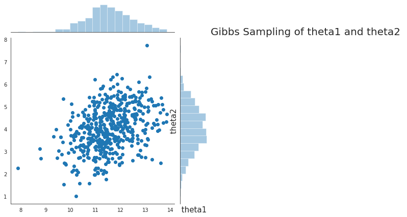

```python
theta_1, theta_2 = gibbs_sampler_mu(mus, r, iters=1000, warmup=500)

with sns.axes_style("white"):
        sns.jointplot(theta_1, theta_2, kind="scatter");

plt.title("Gibbs Sampling of theta1 and theta2 ", fontsize=20, x = 4.5)
plt.xlabel(" theta1 ", fontsize=15)
plt.ylabel(" theta2 ", fontsize=15)
plt.show()
```